# Assignment 5

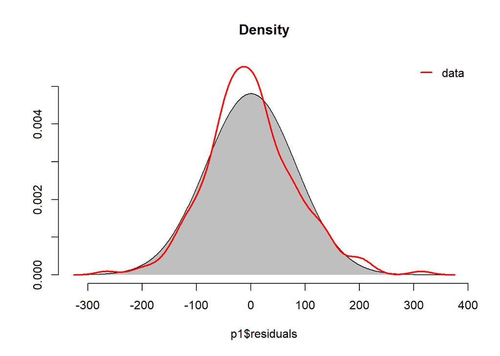

```r
#check normal distribution graph for residuals of m2
check_normaldist(p1$residuals, xlab = 'reaction time (ms)', title = 'residuals distribution p1')
```

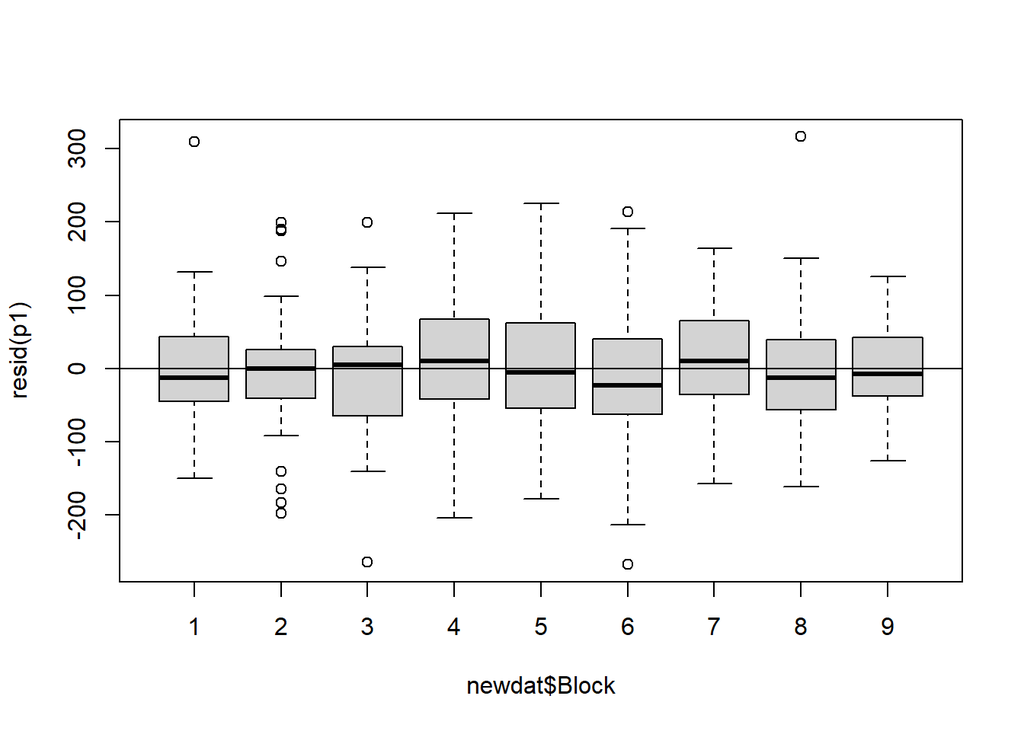

```r
#boxplot
boxplot(resid(p1) ~ newdat$Block)
abline(h=0)
```

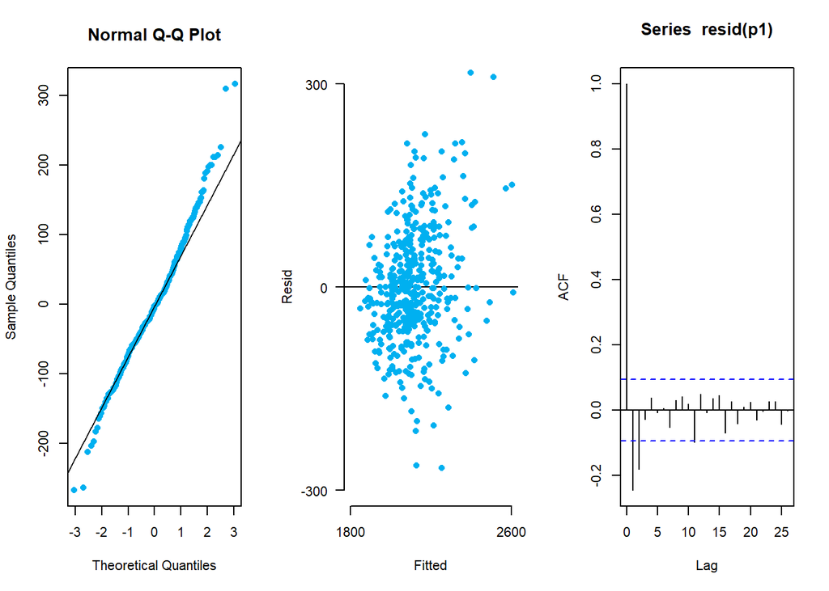

```r
##Summary plots
par(mfrow=c(1,3), cex=0.7)
# PLOT 1
qqnorm(resid(p1), pch=16, col=alpha("#00B0F0"))
qqline(resid(p1))

# PLOT 2
emptyPlot(c(1800, 2600), c(-300, 300),
    h0=0,
    xlab="Fitted", ylab="Resid",
    xmark=TRUE, ymark=TRUE, las=1)
points(fitted(p1), resid(p1), pch=16, col=alpha("#00B0F0"))

# PLOT 3
acf(resid(p1))
```

Further transformations is necessary because the ACF plot shows a correlation. Thus the following random effects and random slopes are added to reduce the correlation.

```r
#adding random effects and slopes
f1 <- bam(RT ~ s(Block, by=Condition, k=4) + s(Subject, bs='re') + s(Subject, Block, bs='re') + s(Block, num, bs='fs', m=1, k=4), data = newdat, method = 'ML' )
summary(f1)
```

```
##
## Family: gaussian
## Link function: identity
##
## Formula:
## RT ~ s(Block, by = Condition, k = 4) + s(Subject, bs = "re") +
##     s(Subject, Block, bs = "re") + s(Block, num, bs = "fs", m = 1,
##     k = 4)
##
## Parametric coefficients:
##             Estimate Std. Error t value Pr(>|t|)
## (Intercept)  2114.26      19.93   106.1   <2e-16 ***
## ---
## Signif. codes:  0 '***' 0.001 '**' 0.01 '*' 0.05 '.' 0.1 ' ' 1
##
## Approximate significance of smooth terms:
##                         edf Ref.df      F  p-value
## s(Block):ConditionDR  1.886  1.990 10.220 3.90e-05 ***
## s(Block):ConditionFF  1.000  1.001 12.436 0.000476 ***
## s(Block):ConditionRD  2.871  2.987  8.213 2.77e-05 ***
## s(Subject)           30.551 47.000 36.774  < 2e-16 ***
## s(Subject,Block)     34.419 47.000 43.029  < 2e-16 ***
## s(Block,num)          2.004  2.007  7.266 0.000796 ***
## ---
## Signif. codes:  0 '***' 0.001 '**' 0.01 '*' 0.05 '.' 0.1 ' ' 1
##
## Rank: 108/109
## R-sq.(adj) =   0.58   Deviance explained = 65.1%
## -ML = 2712.7  Scale est. = 11379     n = 431
```

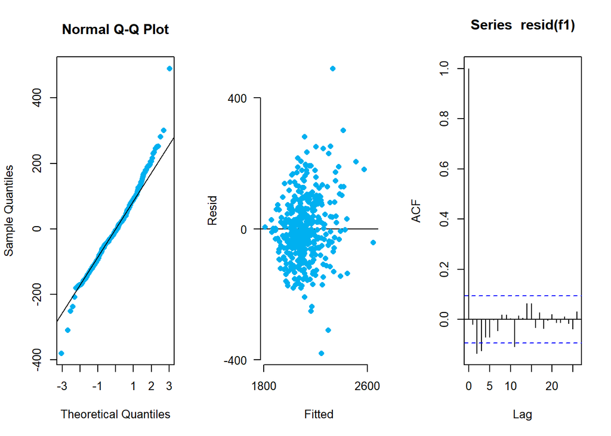

```r
#VISUALIZATION
par(mfrow=c(1,3), cex=0.8)
# PLOT 1
qqnorm(resid(f1), pch=16, col=alpha("#00B0F0"))
qqline(resid(f1))

# PLOT 2
emptyPlot(range(fitted(f1)), range(resid(f1)),
    h0=0,
    xlab="Fitted", ylab="Resid",
    xmark=TRUE, ymark=TRUE, las=1)
points(fitted(f1), resid(f1), pch=16, col=alpha("#00B0F0"))

# PLOT 3
acf(resid(f1))
```

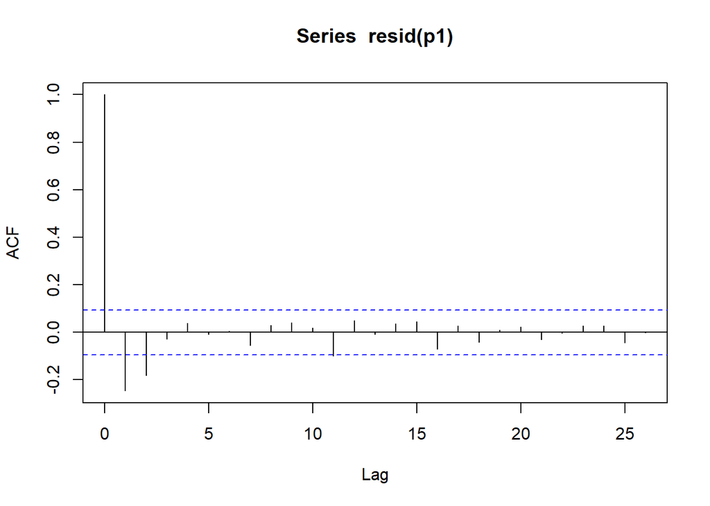

```r
#compare ACF
acf(resid(p1))
```

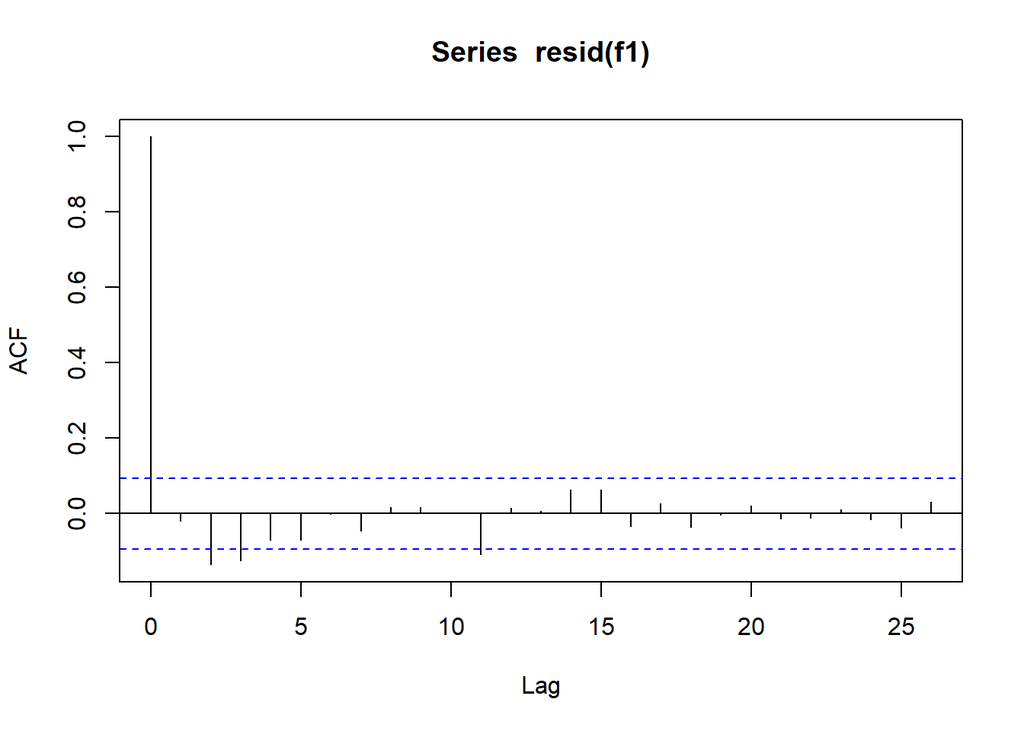

```r
acf(resid(f1))
```

**Compare this analysis (i.e., participant averages per block) with our original analysis (i.e., including all observations). Are the conclusions the same? What are the advantages/disadvantages of these analyses?**

```r
summary(m2)
```

```
##
## Family: gaussian
## Link function: identity
##
## Formula:
## RT ~ Condition + s(Trial, by = Condition) + s(Trial, Subject,
##     bs = "fs", m = 1)
##
## Parametric coefficients:
##             Estimate Std. Error t value Pr(>|t|)
## (Intercept)  2085.64      27.11  76.936   <2e-16 ***
## ConditionFF    75.12      38.35   1.959   0.0502 .
## ConditionRD    12.60      38.34   0.329   0.7425
## ---
## Signif. codes:  0 '***' 0.001 '**' 0.01 '*' 0.05 '.' 0.1 ' ' 1
##
## Approximate significance of smooth terms:
##                          edf  Ref.df     F  p-value
## s(Trial):ConditionDR   4.639   5.518 3.895  0.00116 **
## s(Trial):ConditionFF   1.001   1.001 0.307  0.58018
## s(Trial):ConditionRD   6.649   7.656 4.576 8.88e-05 ***
## s(Trial,Subject)     175.917 429.000 2.650  < 2e-16 ***
## ---
## Signif. codes:  0 '***' 0.001 '**' 0.01 '*' 0.05 '.' 0.1 ' ' 1
##
## R-sq.(adj) =  0.133   Deviance explained = 15.2%
## fREML =  64350  Scale est. = 1.3517e+05  n = 8761
```

```r
summary(f1)
```

```
##
## Family: gaussian
## Link function: identity
##
## Formula:
## RT ~ s(Block, by = Condition, k = 4) + s(Subject, bs = "re") +
##     s(Subject, Block, bs = "re") + s(Block, num, bs = "fs", m = 1,
##     k = 4)
##
## Parametric coefficients:
##             Estimate Std. Error t value Pr(>|t|)
## (Intercept)  2114.26      19.93   106.1   <2e-16 ***
## ---
## Signif. codes:  0 '***' 0.001 '**' 0.01 '*' 0.05 '.' 0.1 ' ' 1
##
## Approximate significance of smooth terms:
##                         edf Ref.df      F  p-value
## s(Block):ConditionDR  1.886  1.990 10.220 3.90e-05 ***
## s(Block):ConditionFF  1.000  1.001 12.436 0.000476 ***
## s(Block):ConditionRD  2.871  2.987  8.213 2.77e-05 ***
## s(Subject)           30.551 47.000 36.774  < 2e-16 ***
## s(Subject,Block)     34.419 47.000 43.029  < 2e-16 ***
## s(Block,num)          2.004  2.007  7.266 0.000796 ***
## ---
## Signif. codes:  0 '***' 0.001 '**' 0.01 '*' 0.05 '.' 0.1 ' ' 1
##
## Rank: 108/109
## R-sq.(adj) =   0.58   Deviance explained = 65.1%
## -ML = 2712.7  Scale est. = 11379     n = 431
```

The model with all observation (m2) accounts for the difference in RTs over the trials. On the other hand, f1 indicates the difference in RTs for conditions over each block. Here each block is a mini-time series and can better show the trend over trials and participant. Moreover, the non-linear trend between subjects and blocks captures a variance of each subject for a particular time-series performed.